# Final Project: Predicting High Risk Individuals for Ovarian Cancer Using NHANES (1988-2018)

Option 2: Explore a provided dataset for pre-specified research goals (Category D: Construct a prediction model to identify individuals with an outcome of interest in an unseen dataset) | Dataset: W_NHANES

YaYin Ruan

2026-05-02

# 1. Background

Ovarian cancer is the fifth leading cause of cancer deaths among women. The difficulty surrounding ovarian cancer diagnosis poses great public health interests. Ovarian cancer early symptoms are non-specific, and patients/physicians may not connect the symptoms with ovarian cancer. This is evident as only 20% of diagnosis occur in the early stages (I and II), and diagnosis at the later stages have less optimistic outlooks with approximately 20% long term survival rate.Current machine learning models for ovarian cancer focus on pathology, imaging, and biopsy classification. Therefore we have a gap in research surrounding the use of machine learning and prediction of ovarian cancer outcome using population level data. This project aims to develop a population-level prediction model using NHANES data, that may be helpful in understanding an individual’s risk of ovarian cancer. Difficulty surrounding the use of NHANES is that this is a cross sectional study, so there are no establishments in temporality, which limits the causal inference of this machine learning model.

# 2. Research Question (predictive question)

Can we develop a machine learning prediction model to identify individuals with a high probability of ovarian cancer using demographic and clinical variables in NHANES (1988-2018)?

## Step 1 (creating outcome)

```r
load("NHANES.RData")

# Creating final ovarian cancer outcome variable from participants who have either MCQ240S non-missing (age at ovarian cancer diagnosis) or those who answered MCQ220=1 (ever had cancer) AND any MCQ230 = 37 (ovarian)
questionnaire_clean <- questionnaire_clean %>%
  mutate(ovarian_mcq240s = as.integer(!is.na(MCQ240S)),
    ovarian_mcq230 = as.integer(MCQ220 == 1 & (MCQ230A == 37 | MCQ230B == 37 | MCQ230C == 37 | MCQ230D == 37)),
    ovarian_mcq230 = replace_na(ovarian_mcq230, 0),
    ovarian_cancer = as.integer(ovarian_mcq240s == 1 | ovarian_mcq230 == 1)
  )
```

```
## Outcome distribution (0 = No ovarian cancer, 1 = Ovarian cancer):
```

```
##
##      0      1   <NA>
## 134263    252      0
```

From the entire NHANES dataset we have 252 participants with outcome (ovarian cancer)

# Step 1.2 Predictors

Predictors were selected based on established ovarian cancer risk factors from the epdimiological literature.

```r
# Recoding features of interest from questionnaire data set: Personal history of breast cancer (MCQ230A-D: code 14 = breast cancer), Nulliparity (never pregnant) (RHQ160: ever been pregnant (1=Yes, 2=No)), Early menarche (age at first period <= 11) (RHQ010: age at first menstrual period), Late menopause (age periods stopped >= 55) (RHD180: age periods stopped; RHQ031: still having periods (1=Yes)), Uterine_fibroid (RHQ380: Ever told by doctor that you had uterine fibroids),Endometriosis (RHQ570: ever told by doctor had endometriosis), Hormone replacement therapy (RHQ540: ever used female hormones (1=Yes, 2=No)), Oral contraceptive use (RHQ420: ever taken birth control pills (1=Yes, 2=No)), Smoking (HAR3)

questionnaire_clean <- questionnaire_clean %>%
  mutate(breast_cancer_hx = as.integer(MCQ230A == 14 | MCQ230B == 14 | MCQ230C == 14 | MCQ230D == 14),
    breast_cancer_hx = replace_na(breast_cancer_hx, 0),
    nulliparous = case_when(RHQ160 == 2 ~ 1L, RHQ160 == 1 ~ 0L, TRUE ~ NA_integer_),
    early_menarche = case_when(RHQ010 %in% c(777, 999) ~ NA_integer_, RHQ010 <= 11 ~ 1L, RHQ010 > 11 ~ 0L, TRUE ~ NA_integer_),
    menopausal_status = case_when(RHQ031 == 2 ~ 1L, RHQ031 == 1 ~ 0L, TRUE ~ NA_integer_
),
  uterine_fibroid = case_when(RHQ380 == 1 ~ 1L, RHQ380 == 2 ~ 0L, TRUE ~ NA_integer_),
  endometriosis = case_when(RHQ570 == 1 ~ 1L, RHQ570 == 2 ~ 0L, TRUE ~ NA_integer_),
  hrt = case_when(RHQ540 == 1 ~ 1L,RHQ540 == 2 ~ 0L, TRUE ~ NA_integer_),
  oral_contraceptive = case_when(RHQ420 == 1 ~ 1L,RHQ420 == 2 ~ 0L, TRUE ~ NA_integer_),
  smoking_questionnaire = case_when(HAR3 == 1 ~ 1L, HAR3 == 2 ~ 0L, TRUE ~ NA_integer_)
  )
```

## Step 1.3 Merging data

Four NHANES modules were merged by participant sequence number (SEQN) and checking for duplicate data

```r
#age, gender, ethnicity, poverty, education
demo_dedup <- demographics_clean %>%
  select(SEQN, RIDAGEYR, RIAGENDR, RIDRETH1, INDFMPIR, DMDEDUC2) %>%
  group_by(SEQN) %>%
  slice(1) %>%
  ungroup()

#overaian cancer outcome, breast cancer history, nulliparous, early menarche, meopausal status, uterine fibroid, endometriosis, hrt, oral contraceptive, smoking
quest_dedup <- questionnaire_clean %>%
  select(SEQN, ovarian_cancer, breast_cancer_hx, nulliparous, early_menarche, menopausal_status, uterine_fibroid, endometriosis, hrt, oral_contraceptive, smoking_questionnaire) %>%
  group_by(SEQN) %>%
  slice(1) %>%
  ungroup()

#BMI and waist circumference
response_dedup <- response_clean %>%
  select(SEQN, BMXBMI, BMXWAIST) %>%
  group_by(SEQN) %>%
  slice(1) %>%
  ungroup()

#fat in diet
dietary_dedup <- dietary_clean %>%
  select(SEQN, DRXTTFAT) %>%
  group_by(SEQN) %>%
  slice(1) %>%
  ungroup()

#joining data and recoidng BMI data to create obesity predictor and creating high fat diet preidctor
df <- quest_dedup %>%
  left_join(demo_dedup, by = "SEQN") %>%
  left_join(response_dedup, by = "SEQN") %>%
  left_join(dietary_dedup, by = "SEQN") %>%
  mutate(
    obese = case_when(
      BMXBMI >= 30 ~ 1L,
      BMXBMI < 30 ~ 0L,
      TRUE ~ NA_integer_
    ),
    high_fat_diet = as.integer(DRXTTFAT > quantile(DRXTTFAT, 0.75, na.rm = TRUE))
  )


# Verify no more duplicates
cat("Unique SEQNs in df:", n_distinct(df$SEQN), "\n")
```

```
## Unique SEQNs in df: 101316
```

```r
cat("Total rows in df:", nrow(df), "\n")
```

```
## Total rows in df: 101316
```

```r
table(df$ovarian_cancer, useNA = "always")
```

```
##
##      0      1   <NA>
## 101130    186      0
```

## Step 1.5 Sample restriction

The analytic sample was restricted to adult females aged 18 years and older with non-missing ovarian cancer outcome.

```r
df <- df %>%
  filter(
    RIAGENDR == 2,
    RIDAGEYR >= 18,
    !is.na(ovarian_cancer)
  ) %>%
  mutate(across(where(is.numeric),
                ~ ifelse(. %in% c(7, 9, 77, 99, 777, 999), NA, .)))
```

```
## Cohort size: 31079
```

```
## Ovarian cancer cases: 164
```

```
## Prevalence: 0.528 %
```

Final total sample size after cleaning/restriction N = 31079, number of participants with outcome = 164, prevalence of ovarian cancer in dataset is 0.528

## 3.6 Feature Selection and Missing Data

```r
features <- c(
  "RIDAGEYR",
  "breast_cancer_hx",
  "nulliparous",
  "early_menarche",
  "menopausal_status",
  "uterine_fibroid",
  "endometriosis",
  "hrt",
  "oral_contraceptive",
  "smoking_questionnaire",
  "obese",
  "BMXWAIST",
  "high_fat_diet"
)
```

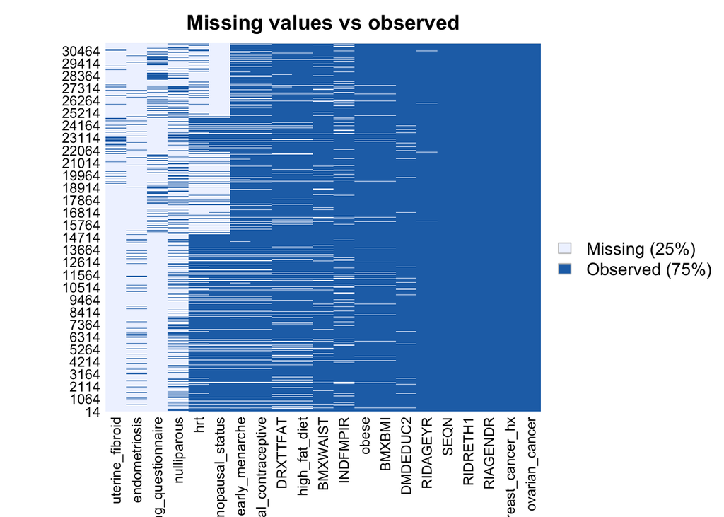

Figure 1: Percentage of Missing Values by Predictor Variable

Uterine fibroid, endometriosis, and smoking exhibited high levels of missingness and were excluded from the final feature set. The remaining predictors were retained for imputation.

```r
features <- c(
  "RIDAGEYR",
  "breast_cancer_hx",
  "nulliparous",
  "early_menarche",
  "menopausal_status",
  "hrt",
  "oral_contraceptive",
  "obese",
  "BMXWAIST",
  "high_fat_diet"
)
```

## Step 2 Test/train data split

Data were split into 70% training and 30% test sets using stratified sampling to preserve the outcome distribution.

```r
set.seed(42)
train_idx <- createDataPartition(df$ovarian_cancer, p = 0.70, list = FALSE)
train_df <- df[train_idx, ]
test_df  <- df[-train_idx, ]
```

```
## Train size: 21756 | Ovarian cancer cases: 119
```

```
## Test size: 9323 | Ovarian cancer cases: 45
```

## Step 3 Imputation

Missing values were imputed using k-nearest neighbor imputation (k=3) applied separately to the training and test sets. The outcome variable was excluded from imputation.

```r
train_outcome <- train_df$ovarian_cancer
test_outcome  <- test_df$ovarian_cancer

df_train_x <- train_df %>% select(all_of(features))
df_test_x  <- test_df %>% select(all_of(features))

set.seed(42)
df_train_imp <- kNN(df_train_x, k = 3, imp_var = FALSE)
df_test_imp  <- kNN(df_test_x,  k = 3, imp_var = FALSE)
```

## Step 3.1 Data preparation for training models

Binary predictors were converted to factors. The outcome variable was added back after imputation.

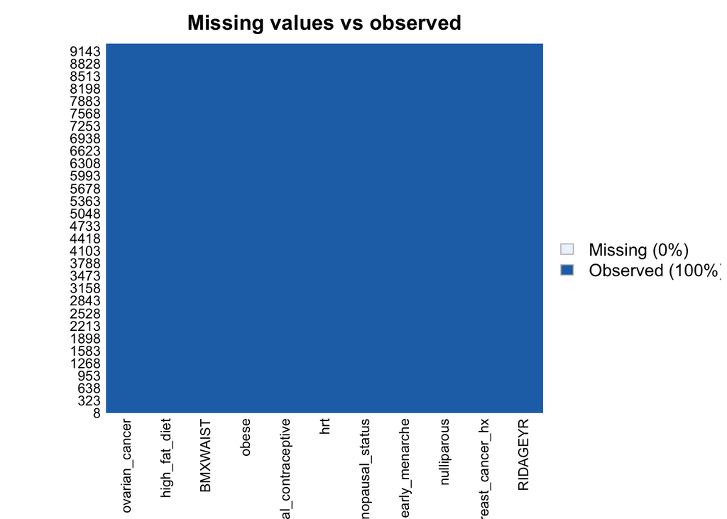

```r
#adding predictor back
df_train_model <- df_train_imp %>%
mutate(ovarian_cancer = factor(train_outcome, levels = c(0, 1), labels = c("No", "Yes")))

df_test_model <- df_test_imp %>%
mutate(ovarian_cancer = factor(test_outcome, levels = c(0, 1), labels = c("No", "Yes")))

#check
df_test_model %>%
  missmap(main = "Missing values vs observed")
```

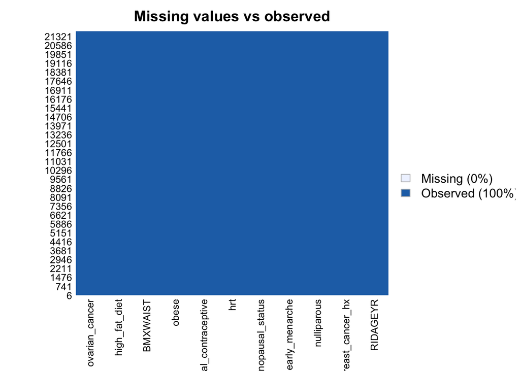

```r
df_train_model %>%
  missmap(main = "Missing values vs observed")
```

```r
#Convert binary/categorical variables to factors
df_train_model <- df_train_model %>%
  mutate(
    # Binary predictors
    across(c(breast_cancer_hx, nulliparous, early_menarche,
             hrt, oral_contraceptive, menopausal_status, obese, high_fat_diet),
           ~ factor(round(.), levels = c(0, 1), labels = c("No", "Yes")))

  )


cat("\nImputation complete. Dataset dimensions:", dim(df_train_model), "\n")
```

```
##
## Imputation complete. Dataset dimensions: 21756 11
```

```r
cat("Ovarian cancer cases:", sum(df_train_model$ovarian_cancer == "Yes"), "\n")
```

```
## Ovarian cancer cases: 119
```

```r
#Convert to factors for test dataset
df_test_model <- df_test_model %>%
  mutate(
    # Binary predictors
    across(c(breast_cancer_hx, nulliparous, early_menarche,
             hrt, oral_contraceptive,obese, menopausal_status, high_fat_diet),
           ~ factor(round(.), levels = c(0, 1), labels = c("No", "Yes")))
  )


cat("\nImputation complete. Dataset dimensions:", dim(df_test_model), "\n")
```

```
##
## Imputation complete. Dataset dimensions: 9323 11
```

```r
cat("Ovarian cancer cases:", sum(df_test_model$ovarian_cancer == "Yes"), "\n")
```

```
## Ovarian cancer cases: 45
```

```r
X_train <- df_train_model %>% select(all_of(features))
y_train <- df_train_model$ovarian_cancer

X_test  <- df_test_model %>% select(all_of(features))
y_test  <- df_test_model$ovarian_cancer


#Train size: 21756 | Positives: 119, Test size: 9323 | Positives: 45
```

```
##
## Train size: 21756 | Positives: 119
```

```
## Test size: 9323 | Positives: 45
```

After split, train data set has 119 cases, and test data set has 45 cases

## Step 4 Cross-Validation Setup

Given the low prevalence of ovarian cancer (~0.5%), upsampling was applied to address imbalance. Five-fold cross-validation was used to evaluate and tune all models. The primary optimization metric was PR-AUC, which is more appropriate than ROC-AUC for severely imbalanced outcomes.

```r
cv_ctrl_up <- trainControl(
  method          = "cv",
  number          = 5,
  classProbs      = TRUE,
  summaryFunction = prSummary,    #Note: prSummary - AUC represents PR-AUC
  savePredictions = "final",
  sampling        = "up"          # upsampling applied within each fold
)

# Parallel processing speed up the training
cl <- makePSOCKcluster(detectCores() - 1)
registerDoParallel(cl)
```

## Step 5 Logistic Regression

```r
set.seed(42)
table(df_train_model$ovarian_cancer, useNA = "always")
```

```
##
##    No   Yes  <NA>
## 21637   119     0
```

```r
cat("\nTraining Logistic Regression with Upsampling...\n")
```

```
##
## Training Logistic Regression with Upsampling...
```

```r
lr_model <- train( ovarian_cancer ~., data = df_train_model,
  method    = "glm",
  metric = "AUC",
  trControl = cv_ctrl_up,
  preProcess = c("center","scale"))
```

```
##   parameter       AUC Precision    Recall         F        AUCSD  PrecisionSD
## 1      none 0.9975165 0.9975706 0.6072934 0.7546995 0.0004628975 0.0001775865
##     RecallSD        FSD
## 1 0.02697141 0.02066985
```

```
##           (Intercept)              RIDAGEYR   breast_cancer_hxYes
##           -0.02123409            0.19581049            0.30947588
##        nulliparousYes     early_menarcheYes  menopausal_statusYes
##           -0.02022915           -0.04155751            0.62628222
##                hrtYes oral_contraceptiveYes              obeseYes
##            0.23012644           -0.10605591            0.09812939
##              BMXWAIST      high_fat_dietYes
##            0.17683710            0.18241864
```

## Step 5.2 Random Forest

Random Forest was tuned over a sequence of mtry values (number of variables tried at each split) tuning using 100 and 500 trees.

```r
#Create grid of values for hypertuning random forest models, sequence of numbers up to X_train (13 features)
mtry.grid <- expand.grid(.mtry = seq(2, ncol(X_train), by = 2))

#RF with 100 trees
set.seed(42)
rf_model <- train(
  ovarian_cancer ~., data = df_train_model,
  method    = "rf",
  metric    = "AUC",
  trControl = cv_ctrl_up,
  tuneGrid=mtry.grid, ntree=100
)
```

```
##   mtry
## 1    2
```

```
##
## Call:
##  randomForest(x = x, y = y, ntree = 100, mtry = param$mtry)
##                Type of random forest: classification
##                      Number of trees: 100
## No. of variables tried at each split: 2
##
##         OOB estimate of  error rate: 15.88%
## Confusion matrix:
##        No   Yes class.error
## No  15523  6114  0.28257152
## Yes   760 20877  0.03512502
```

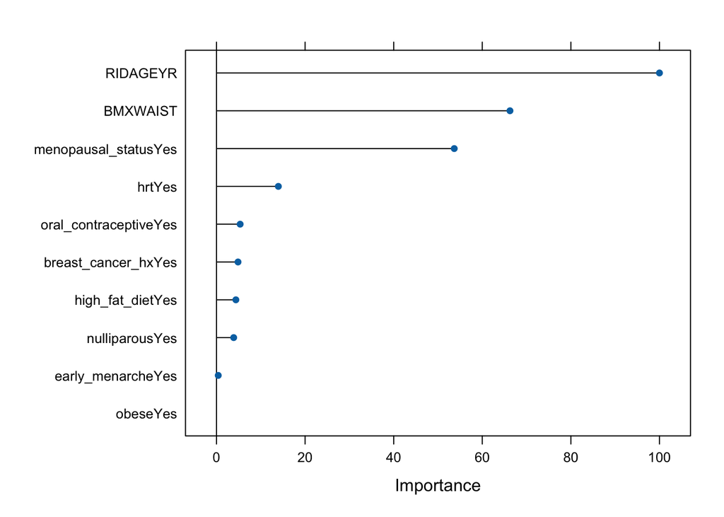

Figure 2: Random Forest Feature Importance

From random forest model with ntrees = 100, the best mtry = 2 (2 randomly selected variables were considered at each tree split). PR-AUC = 0.88618614 which indicates strong ability of the model in correct classification with sensitivity of 0.7367, or 73.67% chance in identifying true positives. The most important variables are age, waist circumference, and menopause status in predicting ovarian cancer.

Random Forest with 500 trees

```r
set.seed(42)
rf_model2 <- train(
  ovarian_cancer ~., data = df_train_model,
  method    = "rf",
  metric    = "AUC",
  trControl = cv_ctrl_up,
  tuneGrid=mtry.grid, ntree =500
)
```

```
##   mtry
## 1    2
```

```
##
## Call:
##  randomForest(x = x, y = y, ntree = 500, mtry = param$mtry)
##                Type of random forest: classification
##                      Number of trees: 500
## No. of variables tried at each split: 2
##
##         OOB estimate of  error rate: 16.55%
## Confusion matrix:
##        No   Yes class.error
## No  14776  6861  0.31709572
## Yes   300 21337  0.01386514
```

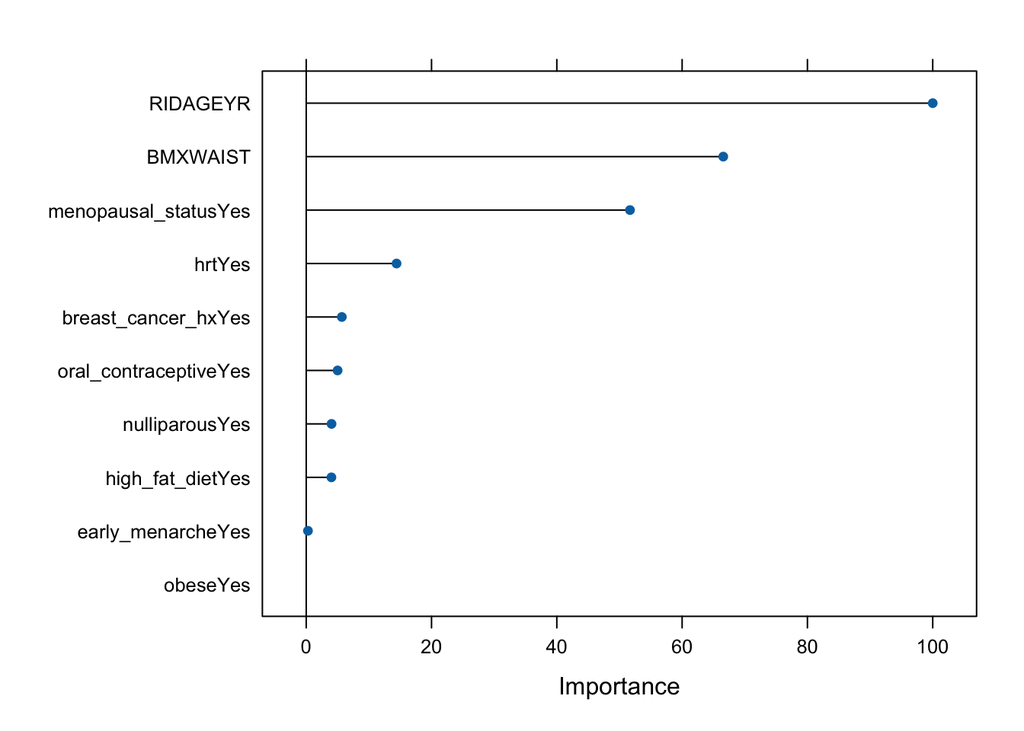

Figure 2: Random Forest Feature Importance

From random forest model with ntrees = 500, the best mtry = 2 (2 randomly selected variables were considered at each tree split). PR-AUC = 0.9578248 which indicates almost perfect classification with sensitivity of 0.7295369, or 72.95% chance in identifying true positives. Random forest with 500 trees has better PR-AUC, therefore will proceed forward with parameter of 500 trees. The most important variables are age, waist circumference, and menopause status in predicting ovarian cancer.

## 5.3 Gradient Boosting

Gradient Boosting was tuned over combinations of number of trees, interaction depth, and shrinkage rate.

```r
set.seed(42)

#tuning grid: trees, shrinkage, depth, minimum number of observations in trees' terminal node
gbm.hyp<-expand.grid(n.trees=(0:10)*100, shrinkage=c(0.01, 0.001), interaction.depth=c(1,3), n.minobsinnode=10)

#GBM model
gbm_model <- train(
  ovarian_cancer ~., data = df_train_model,
  method    = "gbm",
  metric    = "AUC",
  trControl = cv_ctrl_up,
 distribution="bernoulli", verbose=F, tuneGrid=gbm.hyp
)

stopCluster(cl)
```

```
## Best GBM hyperparameters:
```

```
##    n.trees interaction.depth shrinkage n.minobsinnode
## 43     900                 3      0.01             10
```

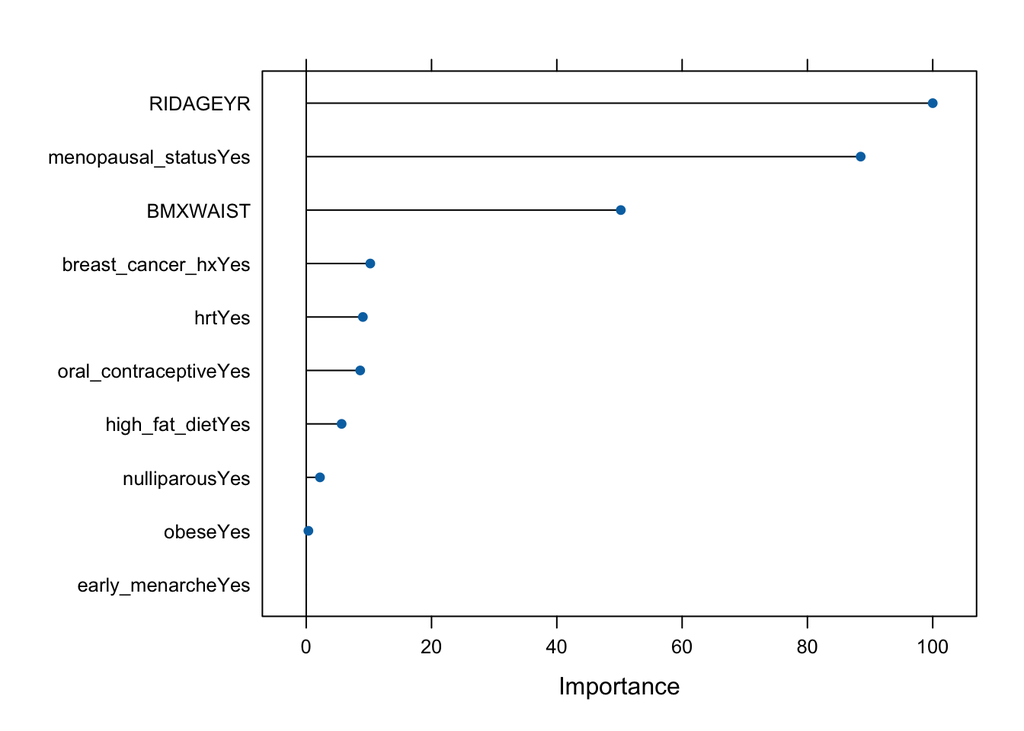

Figure 3: Gradient Boosting Feature Importance

## Step 6: Cross-Validation Performance

All three models were compared on PR-AUC and sensitivity.

Table 1: 5-Fold Cross-Validation Results (Mean ± SD)

| Model | PR-AUC Mean | PR-AUC SD | Sensitivity Mean | Sensitivity SD |
| --- | --- | --- | --- | --- |
| Logistic Regression | 0.9975 | 0.0005 | 0.6073 | 0.0270 |
| Random Forest | 0.9578 | 0.0103 | 0.7295 | 0.0318 |
| Gradient Boosting | 0.9975 | 0.0005 | 0.6901 | 0.0257 |

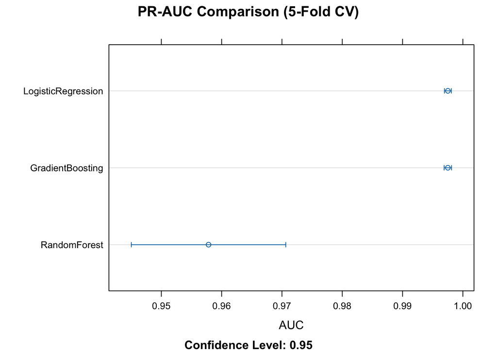

Figure 4: Cross-Validation PR-AUC and Sensitivity Comparison

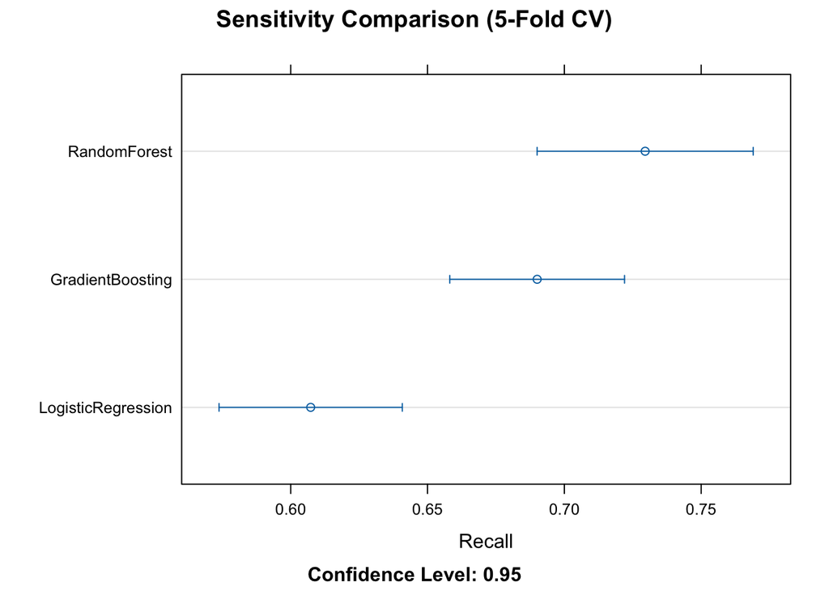

Figure 4: Cross-Validation PR-AUC and Sensitivity Comparison

Gradient Boosting and Logistic Regression achieved similar PR-AUC during cross-validation, both outperforming Random Forest. However, gradient Boosting demonstrated higher sensitivity and was therefore selected as the final model for test set evaluation because it is better at identifying true positives.

## Step 7: test set evaluation

Table 2: GBM Test Set Results — Default Threshold (0.5)

| Metric | Value |
| --- | --- |
| PR-AUC | 0.0150 |
| ROC-AUC | 0.6819 |
| Sensitivity | 0.6000 |
| Specificity | 0.6745 |
| Balanced Accuracy | 0.6372 |
| Precision | 0.0089 |
| F1 | 0.0175 |

Table 3: Confusion Matrix — Default Threshold (0.5)

|  | No | Yes |
| --- | --- | --- |
| No | 6258 | 18 |
| Yes | 3020 | 27 |

# Discussion

## Limitations

Missing other risk factors such as BRCA1/2 genes, which NHANES does not collect information on and family history of ovarian cancer. Cross sectional nature of the data and machine learning models, indicates low causal inferences. The lack of temporality also indicates that this can not be used as a screening tool. Secondly, the algorithms are trained from data that have been imputed and upsampled, so the metrics of PR-AUC from training were highly inflated, which reduces credibility of the models. Secondly, data are self reports which is prone to recall bias.

## Conclusion

This study demonstrates the feasibility of using population-level NHANES data to identify individuals at elevated ovarian cancer risk. The Gradient Boosting model achieved a sensitivity of 0.60 or 60% chance of identifying true positives in datasets. However, the strength of the final GBM model is weak as the balanced accuracy is only 63.72%, better than random chance but not very strong and very low PR-AUC. Very importantly, the nature of cross sectional study, indicates that this can not be used as a screening tool, but it might serve as supplemental risk stratification tool if further developed in future studies using more robust dataset.

Disclaimer: Claude AI was utilized to trouble shoot coding